# DHARMa - Residual Diagnostics for HierArchical (Multi-level / Mixed) Regession Models

Florian Hartig

**Summary**: The DHARMa package creates easily interpretable, residuals for generalized linear mixed models that are standardized to values between 0 and 1. This is achieved by a simulation-based approach, similar to the Bayesian p-value or the parametric bootstrap: 1) simulate new data from the fitted model 2) calculate the cummulative empirical density function 3) residual is the value of the empirical density function at the value of the observed data.

### Installing the package

If you haven’t installed the package yet, run

```r
library(devtools)
install_url("https://dl.dropboxusercontent.com/s/hlg8j0d85ftijem/DHARMa_0.0.0.9000.tar.gz", dependencies = T)
```

### Loading the package

```r
set.seed(1)
library(DHARMa)
citation("DHARMa")
```

```
##
##
##   Florian Hartig (). DHARMa: Residual Diagnostics for HierArchical
##   (Multi-level / Mixed) Regession Models. R package version
##   0.0.0.9000.
##
## A BibTeX entry for LaTeX users is
##
##   @Manual{,
##     title = {DHARMa: Residual Diagnostics for HierArchical (Multi-level / Mixed) Regession Models},
##     author = {Florian Hartig},
##     note = {R package version 0.0.0.9000},
##   }
```

# Workflow in DHARMa

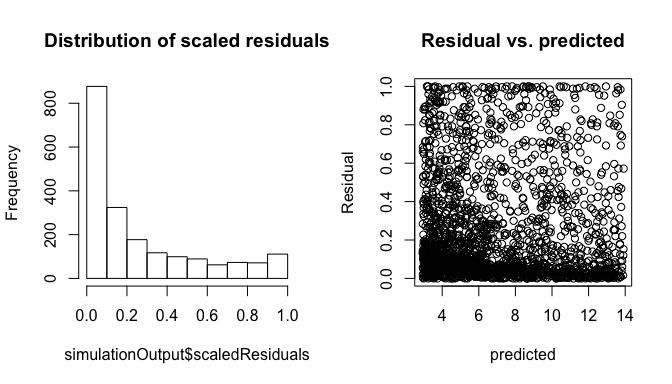

```r
# Some test data
testData = createData(sampleSize = 2000, overdispersion = 2, family = poisson())

# a fitted lme4 model
library(lme4)
fittedModel <- glmer(observedResponse ~ Environment1 + (1|group) , family = "poisson", data = testData)

# The function simulateResiduals() in DHARMa creats standardized residuals
simulationOutput <- simulateResiduals(fittedModel = fittedModel)

# You can plot the residuals with the plotSimulatedResiduals() function
plotSimulatedResiduals(simulationOutput = simulationOutput)
```

The above exampel shows a misspecified model. The reason is that we created data with overdispersion, but the fitted model does not include overdispersion. For a correctly specified model, one would expect

- a flat histogram of the scaled residuals
- no pattern against the fitted value

A bit later in this tutorial, we can see that this is indeed the case if we correct the model structure.

You don’t have to rely on the plots that are provided. It is *highly recommeded* to plot residuals against (where possible)

- all predictors
- space
- time

For that purpose, you can retrieve the residuals via

```r
simulationOutput$scaledResiduals
```

Note again that the residual values are scaled between 0 and 1.

If you plot the residuals against predictors, space or time, the resulting plots should not only show no systematic dependency of those residuals on the covariates, but they should also again be flat for each fixed situation. That means that if you have, for example, a categorical predictor: treatment / control, the distribution of residuals for each predictor alone should be flat as well.

# Example - residual analysis for a mixed Poisson model with overdispersion

Create data with medium overdispersion

```r
testData = createData(sampleSize = 2000, overdispersion = 2, family = poisson())
# see ?createPoissonData for paramter values
```

### Fitting a model without overdispersion on overdispersed data

```r
library(lme4)
fittedModel <- glmer(observedResponse ~ Environment1 + (1|group) , family = "poisson", data = testData)
summary(fittedModel)
```

```
## Generalized linear mixed model fit by maximum likelihood (Laplace
##   Approximation) [glmerMod]
##  Family: poisson  ( log )
## Formula: observedResponse ~ Environment1 + (1 | group)
##    Data: testData
##
##       AIC       BIC    logLik  deviance  df.resid
##  342374.9  342391.7 -171184.4  342368.9      1997
##
## Scaled residuals:
##    Min     1Q Median     3Q    Max
## -31.69  -2.92  -0.92   0.50 931.55
##
## Random effects:
##  Groups Name        Variance Std.Dev.
##  group  (Intercept) 1.984    1.408
## Number of obs: 2000, groups:  group, 10
##
## Fixed effects:
##              Estimate Std. Error z value Pr(>|z|)
## (Intercept)   1.25560    0.44495    2.82  0.00477 **
## Environment1  2.95760    0.01227  241.03  < 2e-16 ***
## ---
## Signif. codes:  0 '***' 0.001 '**' 0.01 '*' 0.05 '.' 0.1 ' ' 1
##
## Correlation of Fixed Effects:
##             (Intr)
## Environmnt1 -0.018
```

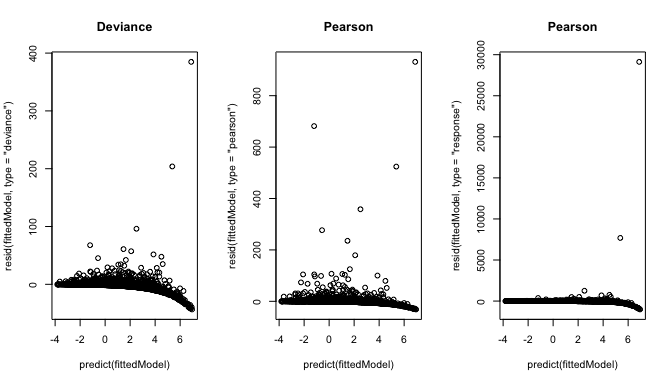

```r
par(mfrow = c(1,3))
plot(predict(fittedModel), resid(fittedModel, type = "deviance"), main = "Deviance" )
plot(predict(fittedModel), resid(fittedModel, type = "pearson") , main = "Pearson")
plot(predict(fittedModel), resid(fittedModel, type = "response") , main = "Pearson" )
```

Simulated Residuals

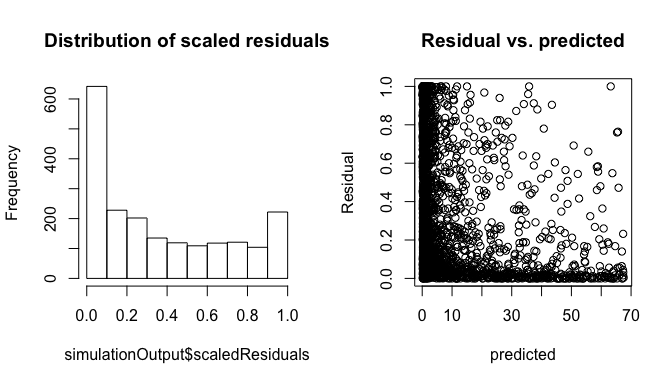

```r
simulationOutput <- simulateResiduals(fittedModel = fittedModel)
plotSimulatedResiduals(simulationOutput = simulationOutput)
```

The U-shaped distrituion in the histogram shows overdispersion

### Fitting a model with overdispersion on the same data

Standard analysis + standard residuals

```r
fittedModel <- glmer(observedResponse ~ Environment1 + (1|group) + (1|ID) , family = "poisson", data = testData)
summary(fittedModel)
```

```
## Generalized linear mixed model fit by maximum likelihood (Laplace
##   Approximation) [glmerMod]
##  Family: poisson  ( log )
## Formula: observedResponse ~ Environment1 + (1 | group) + (1 | ID)
##    Data: testData
##
##      AIC      BIC   logLik deviance df.resid
##  10325.2  10347.6  -5158.6  10317.2     1996
##
## Scaled residuals:
##      Min       1Q   Median       3Q      Max
## -0.88238 -0.50127 -0.10071  0.08256  0.69016
##
## Random effects:
##  Groups Name        Variance Std.Dev.
##  ID     (Intercept) 3.839    1.959
##  group  (Intercept) 1.323    1.150
## Number of obs: 2000, groups:  ID, 2000; group, 10
##
## Fixed effects:
##              Estimate Std. Error z value Pr(>|z|)
## (Intercept)   0.06712    0.36871   0.182    0.856
## Environment1  0.99589    0.09090  10.956   <2e-16 ***
## ---
## Signif. codes:  0 '***' 0.001 '**' 0.01 '*' 0.05 '.' 0.1 ' ' 1
##
## Correlation of Fixed Effects:
##             (Intr)
## Environmnt1 -0.019
```

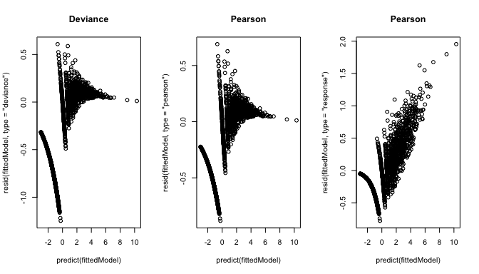

```r
par(mfrow = c(1,3))
plot(predict(fittedModel), resid(fittedModel, type = "deviance"), main = "Deviance" )
plot(predict(fittedModel), resid(fittedModel, type = "pearson") , main = "Pearson")
plot(predict(fittedModel), resid(fittedModel, type = "response") , main = "Pearson" )
```

Simulated Residuals

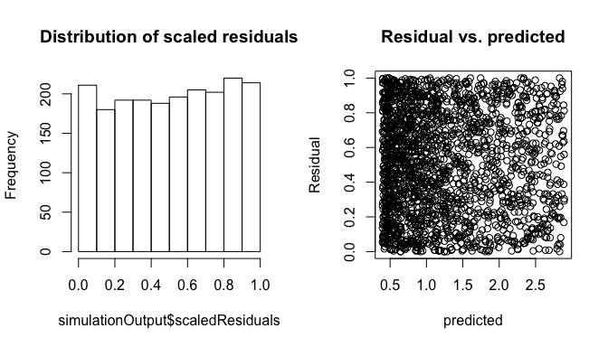

```r
simulationOutput <- simulateResiduals(fittedModel = fittedModel)
plotSimulatedResiduals(simulationOutput = simulationOutput)
```

# Example - residual analysis for a mixed Binomial model

```r
testData = createData(sampleSize = 2000, overdispersion = 2, family = binomial())
# see ?createPoissonData for paramter values
```

Standard analysis + standard residuals

```r
fittedModel <- glmer(observedResponse ~ Environment1 + (1|group) , family = "binomial", data = testData)
summary(fittedModel)
```

```
## Generalized linear mixed model fit by maximum likelihood (Laplace
##   Approximation) [glmerMod]
##  Family: binomial  ( logit )
## Formula: observedResponse ~ Environment1 + (1 | group)
##    Data: testData
##
##      AIC      BIC   logLik deviance df.resid
##   2645.1   2661.9  -1319.5   2639.1     1997
##
## Scaled residuals:
##     Min      1Q  Median      3Q     Max
## -2.2444 -0.9922  0.5961  0.8692  1.6715
##
## Random effects:
##  Groups Name        Variance Std.Dev.
##  group  (Intercept) 0.2234   0.4727
## Number of obs: 2000, groups:  group, 10
##
## Fixed effects:
##              Estimate Std. Error z value Pr(>|z|)
## (Intercept)   0.22442    0.15660   1.433    0.152
## Environment1  0.52638    0.08281   6.356 2.07e-10 ***
## ---
## Signif. codes:  0 '***' 0.001 '**' 0.01 '*' 0.05 '.' 0.1 ' ' 1
##
## Correlation of Fixed Effects:
##             (Intr)
## Environmnt1 0.006
```

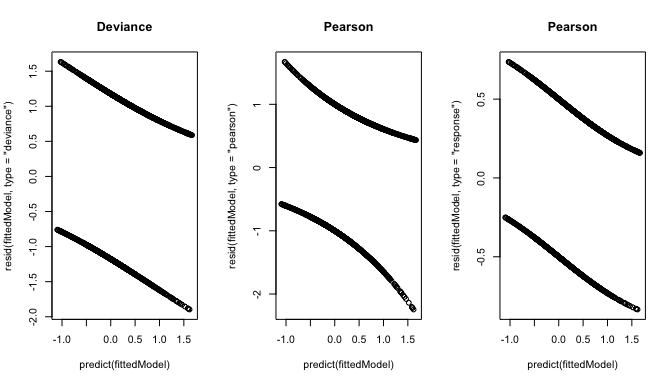

```r
par(mfrow = c(1,3))
plot(predict(fittedModel), resid(fittedModel, type = "deviance"), main = "Deviance" )
plot(predict(fittedModel), resid(fittedModel, type = "pearson") , main = "Pearson")
plot(predict(fittedModel), resid(fittedModel, type = "response") , main = "Pearson" )
```

Simulated Residuals

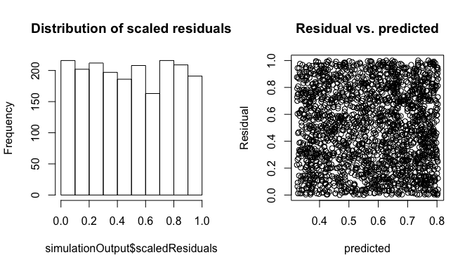

```r
simulationOutput <- simulateResiduals(fittedModel = fittedModel)
plotSimulatedResiduals(simulationOutput = simulationOutput)
```